# Credit Risk Classification with Numeric and Categorical Attributes: Exploring Cost Matrix Impact

## Summary of the data

```python
df.head()
```

|  | checking_balance | months_loan_duration | credit_history | purpose | amount | savings_balance | employment_duration | percent_of_income | years_at_residence | age | other_credit | housing | existing_loans_count | job | dependents | phone | default |
| --- | --- | --- | --- | --- | --- | --- | --- | --- | --- | --- | --- | --- | --- | --- | --- | --- | --- |
| 0 | < 0 DM | 6 | critical | furniture/appliances | 1169 | unknown | > 7 years | 4 | 4 | 67 | none | own | 2 | skilled | 1 | yes | no |
| 1 | 1 - 200 DM | 48 | good | furniture/appliances | 5951 | < 100 DM | 1 - 4 years | 2 | 2 | 22 | none | own | 1 | skilled | 1 | no | yes |
| 2 | unknown | 12 | critical | education | 2096 | < 100 DM | 4 - 7 years | 2 | 3 | 49 | none | own | 1 | unskilled | 2 | no | no |
| 3 | < 0 DM | 42 | good | furniture/appliances | 7882 | < 100 DM | 4 - 7 years | 2 | 4 | 45 | none | other | 1 | skilled | 2 | no | no |
| 4 | < 0 DM | 24 | poor | car | 4870 | < 100 DM | 1 - 4 years | 3 | 4 | 53 | none | other | 2 | skilled | 2 | no | yes |

```python
df.info()
```

```
<class 'pandas.core.frame.DataFrame'>
RangeIndex: 1000 entries, 0 to 999
Data columns (total 17 columns):
 #   Column                Non-Null Count  Dtype
---  ------                --------------  -----
 0   checking_balance      1000 non-null   object
 1   months_loan_duration  1000 non-null   int64
 2   credit_history        1000 non-null   object
 3   purpose               1000 non-null   object
 4   amount                1000 non-null   int64
 5   savings_balance       1000 non-null   object
 6   employment_duration   1000 non-null   object
 7   percent_of_income     1000 non-null   int64
 8   years_at_residence    1000 non-null   int64
 9   age                   1000 non-null   int64
 10  other_credit          1000 non-null   object
 11  housing               1000 non-null   object
 12  existing_loans_count  1000 non-null   int64
 13  job                   1000 non-null   object
 14  dependents            1000 non-null   int64
 15  phone                 1000 non-null   object
 16  default               1000 non-null   object
dtypes: int64(7), object(10)
memory usage: 132.9+ KB
```

```python
df.describe()
```

|  | months_loan_duration | amount | percent_of_income | years_at_residence | age | existing_loans_count | dependents |
| --- | --- | --- | --- | --- | --- | --- | --- |
| count | 1000.000 | 1000.000 | 1000.000 | 1000.000 | 1000.000 | 1000.000 | 1000.000 |
| mean | 20.903 | 3271.258 | 2.973 | 2.845 | 35.546 | 1.407 | 1.155 |
| std | 12.059 | 2822.737 | 1.119 | 1.104 | 11.375 | 0.578 | 0.362 |
| min | 4.000 | 250.000 | 1.000 | 1.000 | 19.000 | 1.000 | 1.000 |
| 25% | 12.000 | 1365.500 | 2.000 | 2.000 | 27.000 | 1.000 | 1.000 |
| 50% | 18.000 | 2319.500 | 3.000 | 3.000 | 33.000 | 1.000 | 1.000 |
| 75% | 24.000 | 3972.250 | 4.000 | 4.000 | 42.000 | 2.000 | 1.000 |
| max | 72.000 | 18424.000 | 4.000 | 4.000 | 75.000 | 4.000 | 2.000 |

```python
df.isnull().values.any()
```

```
False
```

- No missing values in dataset

```python
df.isnull().sum()
```

```
checking_balance        0
months_loan_duration    0
credit_history          0
purpose                 0
amount                  0
savings_balance         0
employment_duration     0
percent_of_income       0
years_at_residence      0
age                     0
other_credit            0
housing                 0
existing_loans_count    0
job                     0
dependents              0
phone                   0
default                 0
dtype: int64
```

```python
cat_col = [
    "checking_balance",
    "credit_history",
    "purpose",
    "savings_balance",
    "employment_duration",
    "other_credit",
    "housing",
    "job",
    "phone",
    "default"]
```

```python
for column in cat_col:
    print(df[column].value_counts())
    print("-" * 40)
```

```
unknown       394
< 0 DM        274
1 - 200 DM    269
> 200 DM       63
Name: checking_balance, dtype: int64
----------------------------------------
good         530
critical     293
poor          88
very good     49
perfect       40
Name: credit_history, dtype: int64
----------------------------------------
furniture/appliances    473
car                     337
business                 97
education                59
renovations              22
car0                     12
Name: purpose, dtype: int64
----------------------------------------
< 100 DM         603
unknown          183
100 - 500 DM     103
500 - 1000 DM     63
> 1000 DM         48
Name: savings_balance, dtype: int64
----------------------------------------
1 - 4 years    339
> 7 years      253
4 - 7 years    174
< 1 year       172
unemployed      62
Name: employment_duration, dtype: int64
----------------------------------------
none     814
bank     139
store     47
Name: other_credit, dtype: int64
----------------------------------------
own      713
rent     179
other    108
Name: housing, dtype: int64
----------------------------------------
skilled       630
unskilled     200
management    148
unemployed     22
Name: job, dtype: int64
----------------------------------------
no     596
yes    404
Name: phone, dtype: int64
----------------------------------------
no     700
yes    300
Name: default, dtype: int64
----------------------------------------
```

### Observations:

- A lot of the data types are objects and in order to work with it in the classification model they would need to be convereted into integers. After conducting the Univariate and Bivariate analysis I will need to transform the data.

### Univariate analysis

[figure not shown]

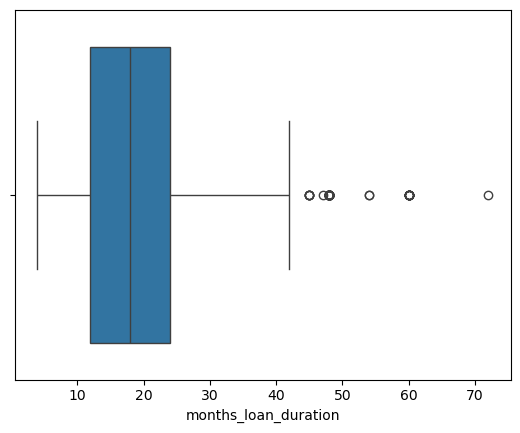

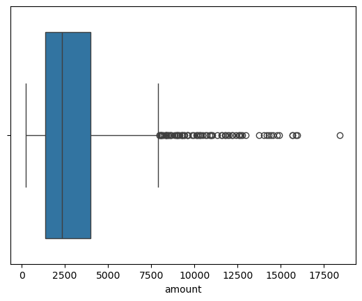

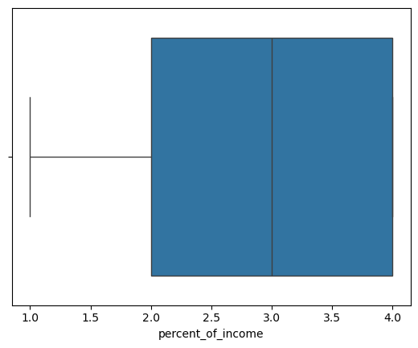

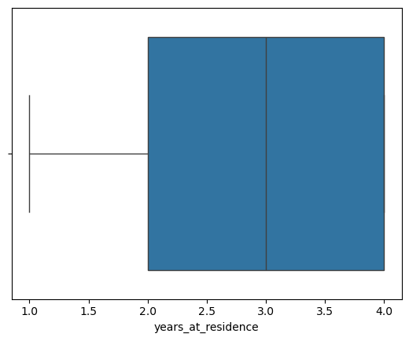

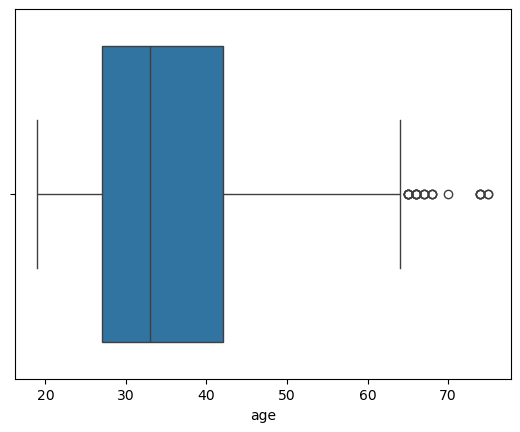

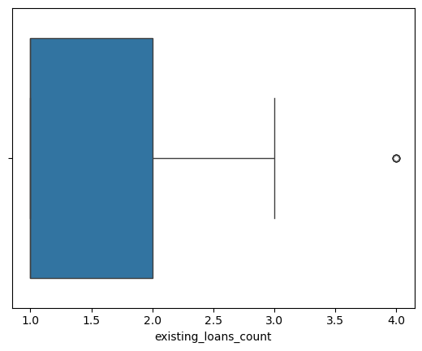

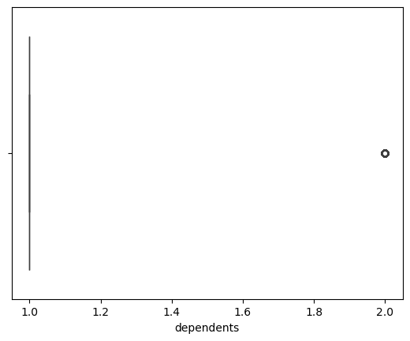

```python
num_cols=df.select_dtypes(include=np.number).columns.tolist()
fig, axes = plt.subplots(nrows=1, ncols=2, figsize=(12, 4))
for num_col in num_cols:
  sns.histplot(data=df,x=num_col,ax=axes[1],kde=True)
  plt.show()
  sns.boxplot(data=df,x=num_col)
  plt.show
```

### Observations:

- There are quite a few outliers in the data
- However, they look like proper values

## Numerical Data

```python
def histogram_boxplot(df, feature, figsize=(15, 10), kde=False, bins=None):
    """
    Boxplot and histogram combined


    data: dataframe
    feature: dataframe column
    figsize: size of figure (default (15,10))
    kde: whether to show the density curve (default False)
    bins: number of bins for histogram (default None)
    """
    f2, (ax_box2, ax_hist2) = plt.subplots(
        nrows=2,  # Number of rows of the subplot grid= 2
        sharex=True,  # x-axis will be shared among all subplots
        gridspec_kw={"height_ratios": (0.25, 0.75)},
        figsize=figsize,
    )  # creating the 2 subplots
    sns.boxplot(
        data=df, x=feature, ax=ax_box2, showmeans=True, color="violet"
    )  # boxplot will be created and a triangle will indicate the mean value of the column
    sns.histplot(
        data=df, x=feature, kde=kde, ax=ax_hist2, bins=bins
    ) if bins else sns.histplot(
        data=df, x=feature, kde=kde, ax=ax_hist2
    )  # For histogram
    ax_hist2.axvline(
        df[feature].mean(), color="green", linestyle="--"
    )  # Add mean to the histogram
    ax_hist2.axvline(
        df[feature].median(), color="black", linestyle="-"
    )  # Add median to the histogram
```

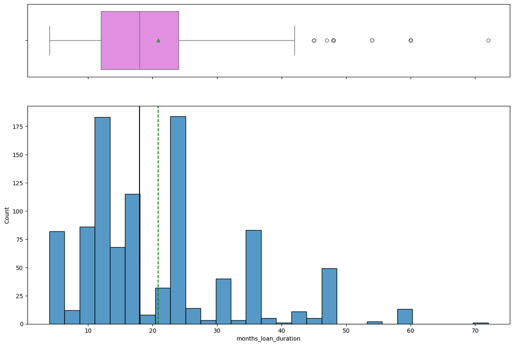

```python
histogram_boxplot(df,"months_loan_duration")
```

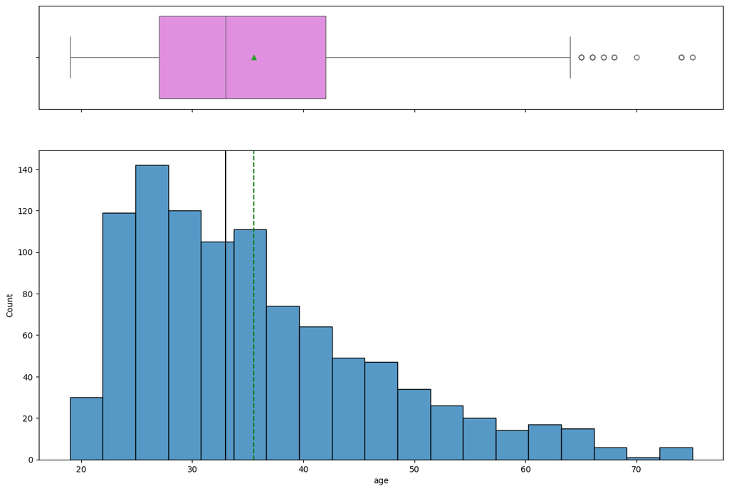

```python
histogram_boxplot(df,"age")
```

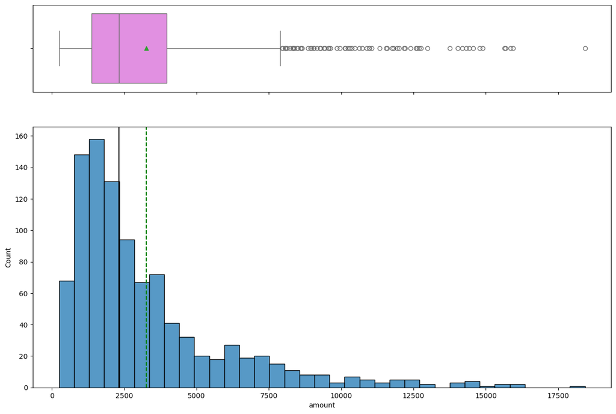

```python
histogram_boxplot(df,"amount")
```

## Categorical Data

```python
def labeled_barplot(df, feature, perc=False, n=None):
    """
    Barplot with percentage at the top


    data: dataframe
    feature: dataframe column
    perc: whether to display percentages instead of count (default is False)
    n: displays the top n category levels (default is None, i.e., display all levels)
    """


    total = len(df[feature])  # length of the column
    count = df[feature].nunique()
    if n is None:
        plt.figure(figsize=(count + 2, 6))
    else:
        plt.figure(figsize=(n + 2, 6))


    plt.xticks(rotation=90, fontsize=15)
    ax = sns.countplot(
        data=df,
        x=feature,
        palette="Paired",
        order=df[feature].value_counts().index[:n],
    )


    for p in ax.patches:
        if perc == True:
            label = "{:.1f}%".format(
                100 * p.get_height() / total
            )  # percentage of each class of the category
        else:
            label = p.get_height()  # count of each level of the category


        x = p.get_x() + p.get_width() / 2  # width of the plot
        y = p.get_height()  # height of the plot


        ax.annotate(
            label,
            (x, y),
            ha="center",
            va="center",
            size=12,
            xytext=(0, 5),
            textcoords="offset points",
        )  # annotate the percentage


    plt.show()  # show the plot
```

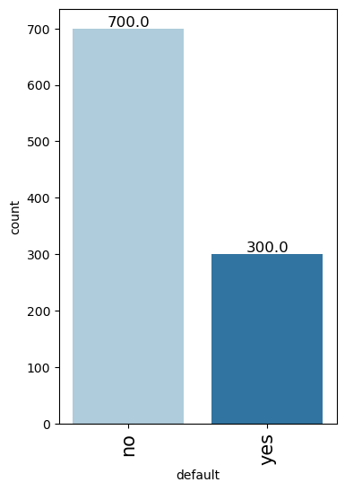

```python
labeled_barplot(df, "default")
```

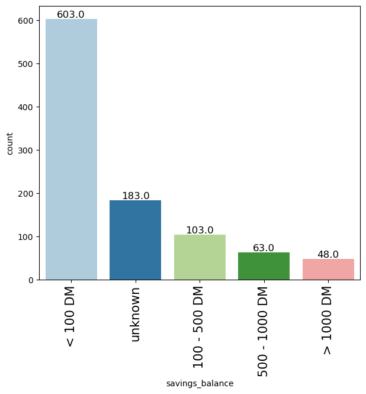

```python
labeled_barplot(df, "savings_balance")
```

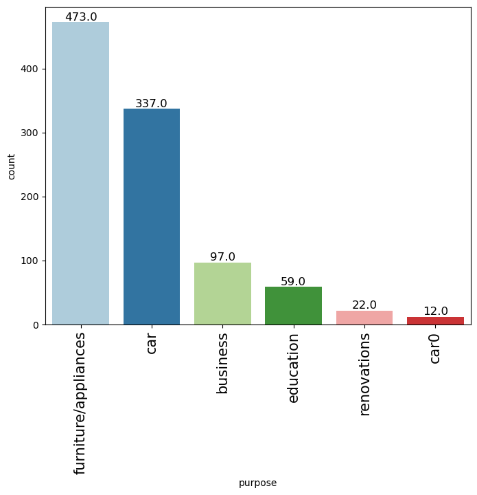

```python
labeled_barplot(df, "purpose")
```

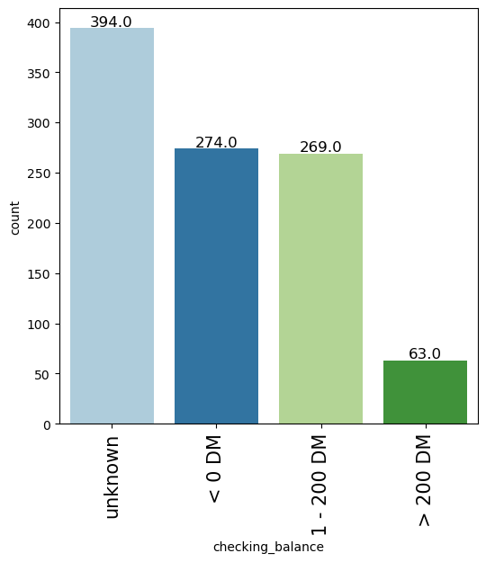

```python
labeled_barplot(df,"checking_balance")
```

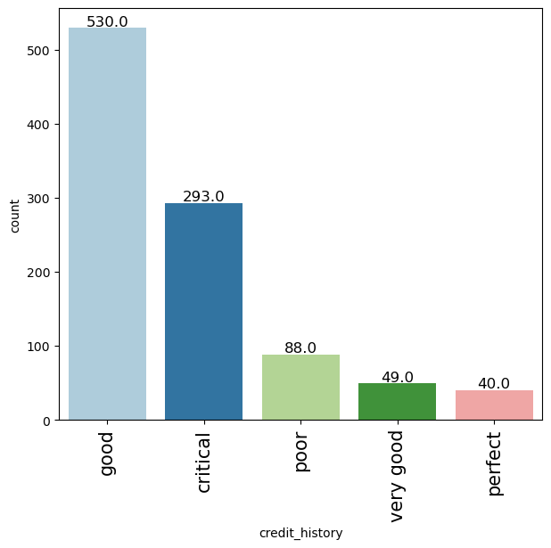

```python
labeled_barplot(df,"credit_history")
```

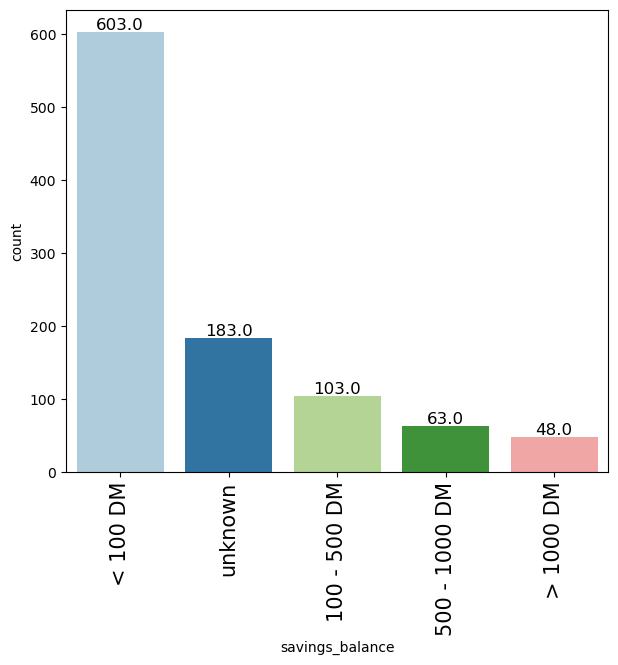

```python
labeled_barplot(df,"savings_balance")
```

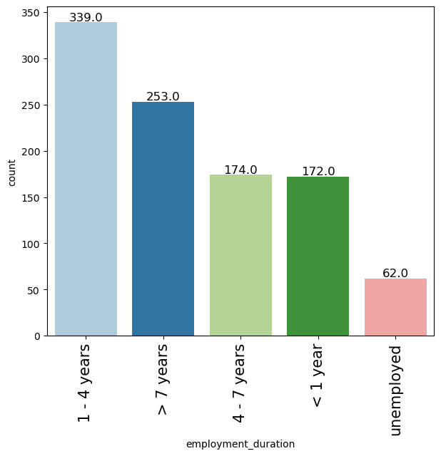

```python
labeled_barplot(df,"employment_duration")
```

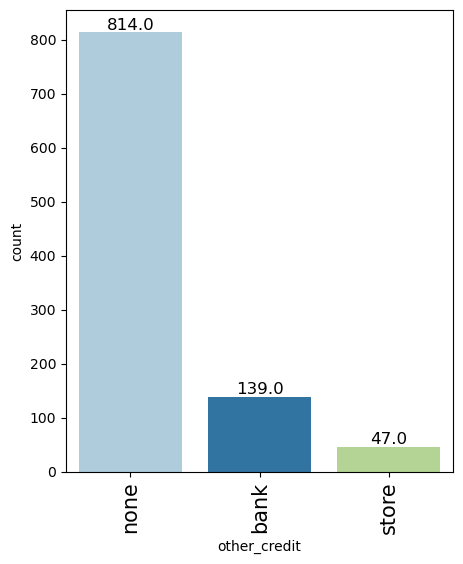

```python
labeled_barplot(df,"other_credit")
```

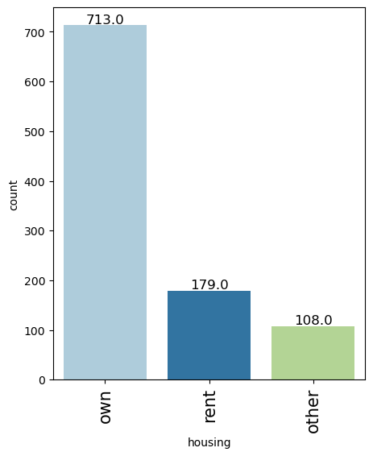

```python
labeled_barplot(df,"housing")
```

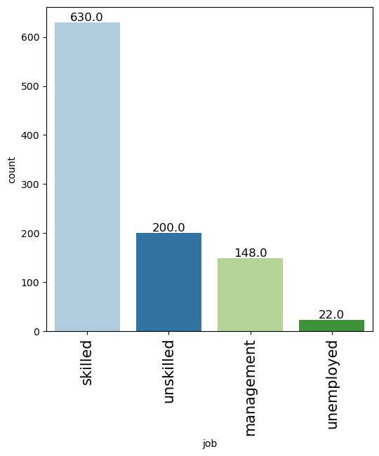

```python
labeled_barplot(df,"job")
```

### Observations:

- **Risk Distribution**: The dataset shows an imbalanced class distribution in the target variable, with 70% non-defaulters and 30% defaulters, indicating a potential need for oversampling or other techniques to address the class imbalance.
- **Housing Ownership**: The majority of customers (71%) who take credit own their houses, followed by 18% living in rented accommodations, and only 11% with free housing provided by their employers, indicating the significance of housing status in credit-seeking behavior.
- **Job Categories**: Most customers (63%) fall into the skilled job category, with only approximately 15% categorized as highly skilled, suggesting that job type may influence creditworthiness and borrowing behavior.
- **Purpose of Credit**: The analysis reveals that most customers take credit for luxury items like cars, radios, furniture/equipment, and domestic appliances, while only around 16% take credit for business or education purposes, indicating consumer-centric rather than investment-driven borrowing patterns.

## Bivariate Analysis

### This analysis will allow us to look deeper and see some of the reasons some associations with defaulting

- Any variations will be useful to build a better model.

```python
def distribution_plot_wrt_target(df, predictor, target):

    fig, axs = plt.subplots(2, 2, figsize=(12, 10))

    target_uniq = df[target].unique()

    axs[0, 0].set_title("Distribution of target for target=" + str(target_uniq[0]))
    sns.histplot(
        data=df[df[target] == target_uniq[0]],
        x=predictor,
        kde=True,
        ax=axs[0, 0],
        color="teal",
        stat="density",
    )

    axs[0, 1].set_title("Distribution of target for target=" + str(target_uniq[1]))
    sns.histplot(
        data=df[df[target] == target_uniq[1]],
        x=predictor,
        kde=True,
        ax=axs[0, 1],
        color="orange",
        stat="density",
    )

    axs[1, 0].set_title("Boxplot w.r.t target")
    sns.boxplot(data=df, x=target, y=predictor, ax=axs[1, 0], palette="gist_rainbow")

    axs[1, 1].set_title("Boxplot (without outliers) w.r.t target")
    sns.boxplot(
        data=df,
        x=target,
        y=predictor,
        ax=axs[1, 1],
        showfliers=False,
        palette="gist_rainbow",
    )

    plt.tight_layout()
    plt.show()
```

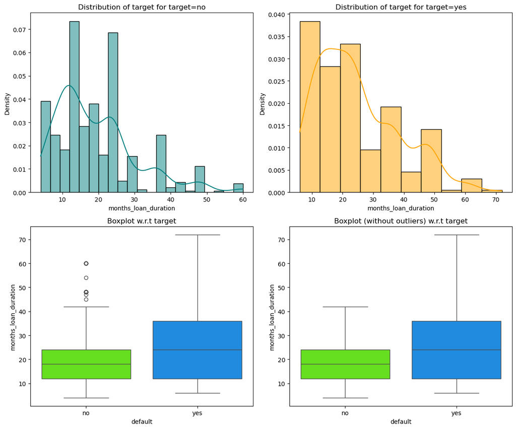

```python
distribution_plot_wrt_target(df, "months_loan_duration", "default")
```

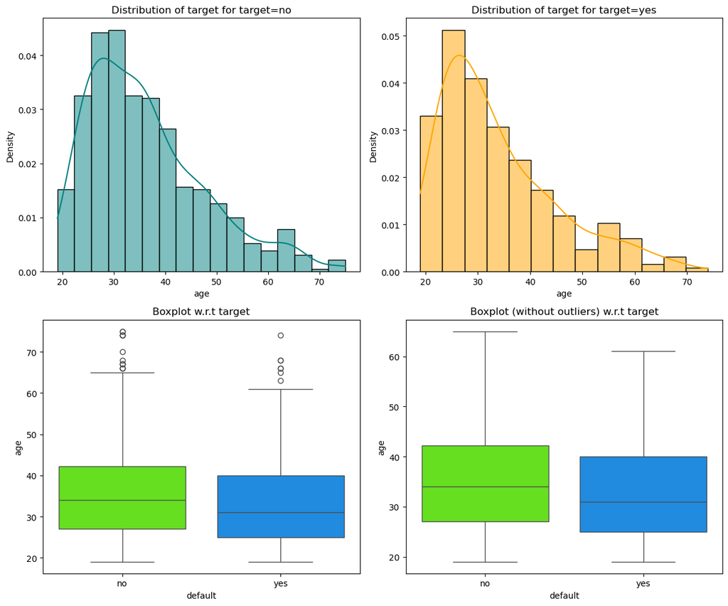

```python
distribution_plot_wrt_target(df, "age", "default")
```

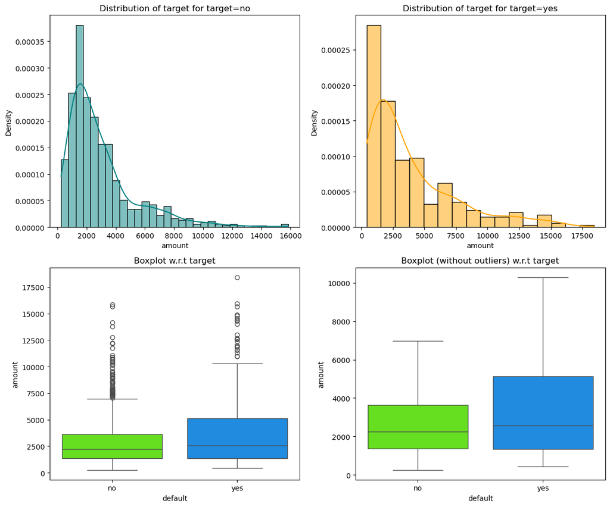

```python
distribution_plot_wrt_target(df, "amount", "default")
```

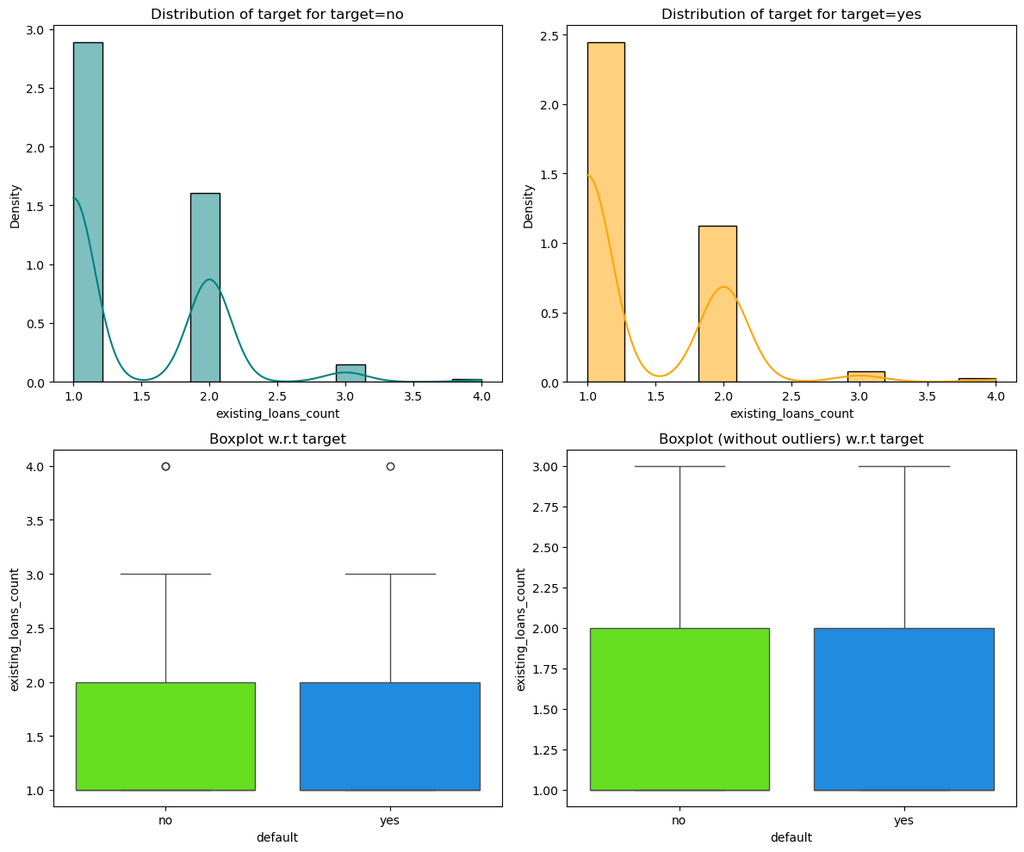

```python
distribution_plot_wrt_target(df, "existing_loans_count", "default")
```